# March Madness

Tracking Auckland’s bus delays through its busiest month

Based on historical and real-time data, updated approximately every 30 minutes, obtained from Auckland Transport’s public GTFS API

# What is “March Madness”?

- Busiest month of the year for public transport
- Buses, trains at capacity
- **Industrial action**: fewer trains during peak, which could increase bus demand
- Starts February 26, when students surge into the CBD
- **The data**:
  - real-time delays from buses
  - historical data from April through November 2017 for comparison

# What does a typical day look like?

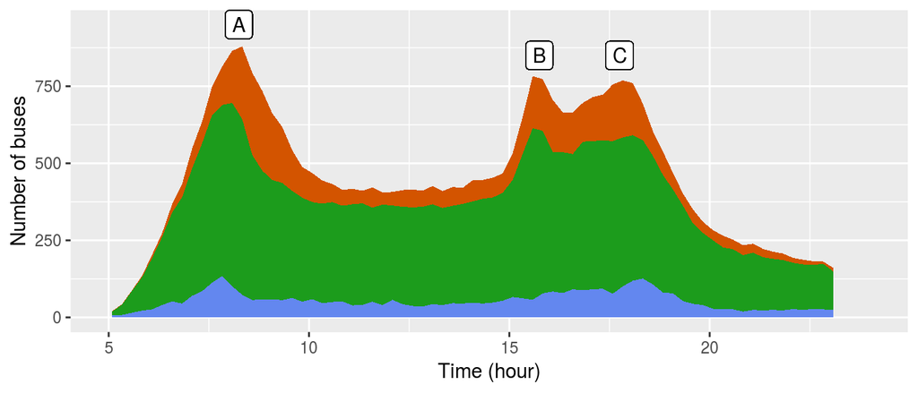

- Peak periods: **A** morning, **B** school, **C** evening
- The coloured areas represent the proportion  
  of buses that are
  - more than 5 minutes early
  - on time (within 5 minutes of schedule)
  - late by more than 5 minutes

# As of 7:50 pm today

- 237 of 314 buses were on time
- 33 were running more than 5 minutes late
- 44 were more than 5 minutes early

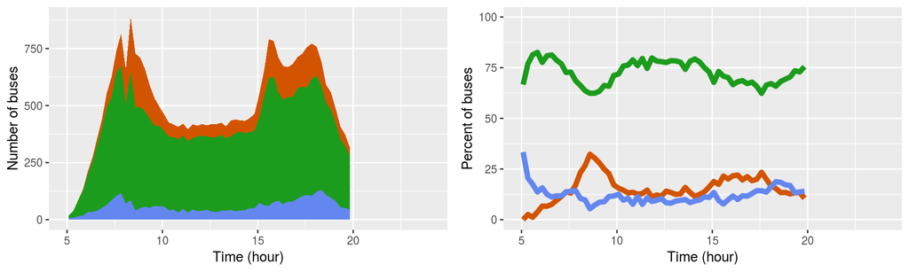

# How does this compare?

- data from April through November 2017
- average percentage of buses **early**, **ontime**, or **late**

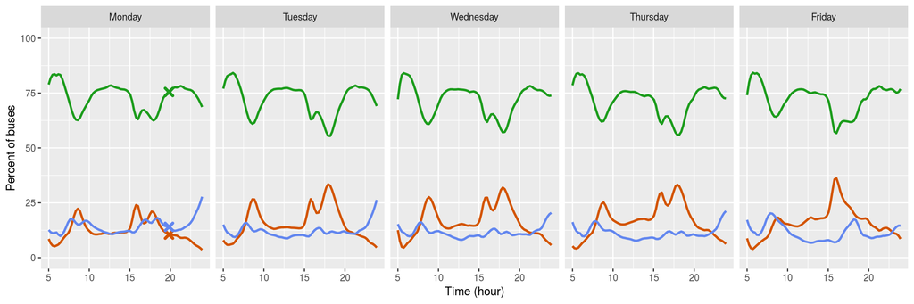

- crosses show current values (as of 7:50 pm)

# March Madness so far: % on-time

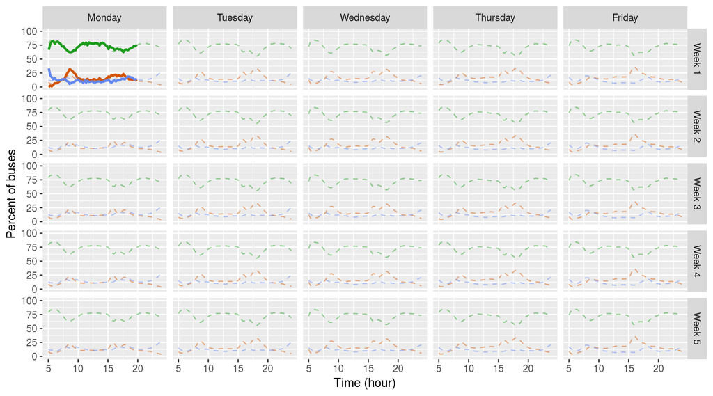

- percentage of buses **early**, **ontime**, or **late**

# But just *how* late (or early)?

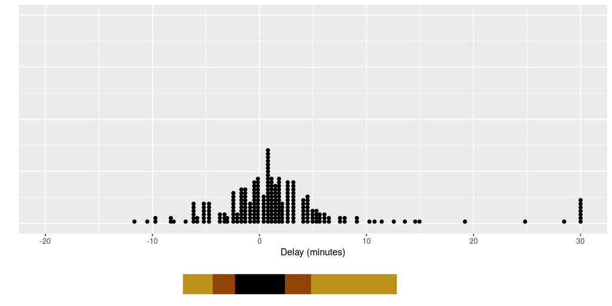

# March Madness so far: delays

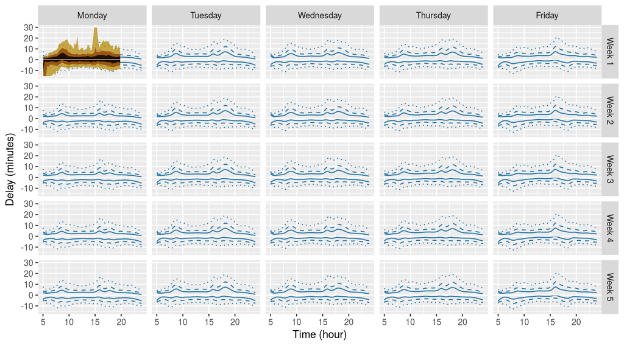

- the regions contain 90%, 75%, and 50% of buses
- historical averages

View the slides here:

bit.ly/madmarch18